# B.F.3 Übung zu Diagnostik/Testtheorie

Item-Response-Theorie

Bißantz, S., Kuch, N. & Gürtler, R.-M.

Rheinland-Pfälzische Technische Universität Kaiserslautern-Landau

Folien als PDF

## Semesterübersicht

| Nr. | Datum | Thema |
| --- | --- | --- |
| 1 | ab 20.10. | Rechenkompetenzen |
| 2 | ab 27.10. | Gütekriterien I |
| 3 | ab 03.11. | Schritte der Testkonstruktion |
| 4 | ab 10.11. | Erstellung eines Testentwurfs |
|  |  | **Lektürewoche** |
| 5 | ab 24.11. | *Diagnostische Rechenkompetenzen I* |
| 6 | ab 01.12. | Klassische Testtheorie |
| 7 | ab 08.12. | *Item-Response-Theorie* |
| 8 | ab 15.12. | Exploratorische Faktorenanalyse I |
|  |  | **Weihnachtsferien** |
| 9 | ab 05.01. | *Exploratorische Faktorenanalyse II* |
| 10 | ab 12.01. | Itemanalyse I |
| 11 | ab 19.01. | Itemanalyse II, Itemselektion und Testrevision |
| 12 | ab 26.01. | *Diagnostische Rechenkompetenzen II* |
| 13 | ab 02.02. | Gütekriterien II |

## Item-Response-Theorie

**Annahme**

Eine oder mehrere latente Fähigkeiten beeinflussen die Wahrscheinlichkeit, dass ein bestimmtes Testverhalten gezeigt wird.

- Latente Fähigkeit/Eigenschaft nicht beobachtbar
- Testverhalten (Antworten auf die Items) beobachtbar

[figure not shown]

## Item-Response-Theorie

- Erlaubt es, Personen und Items auf einem latenten Kontinuum zu verorten
- Besonderheit: dichotome (oder auch kategorial geordnete) Antworten
- Idee: Lösungswahrscheinlichkeit eines Items ist abhängig von der latenten Merkmalsausprägung einer Person und der Aufgabenschwierigkeit
- Modelle:
  - Rasch-Modell (1PL)
  - Birnbaum-Modell (2PL)
  - 3PL-Modelle, …

# Rasch-Modell

## Rasch-Modell

**Annahmen**

- Eine kontinuierliche latente Variable, die das interessierende Konstrukt repräsentiert
- Erfassung des Konstrukts mithilfe von dichotomen Items
- Schätzung von Personenfähigkeit und Itemschwierigkeit auf einer gemeinsamen Skala

## Rasch-Modell

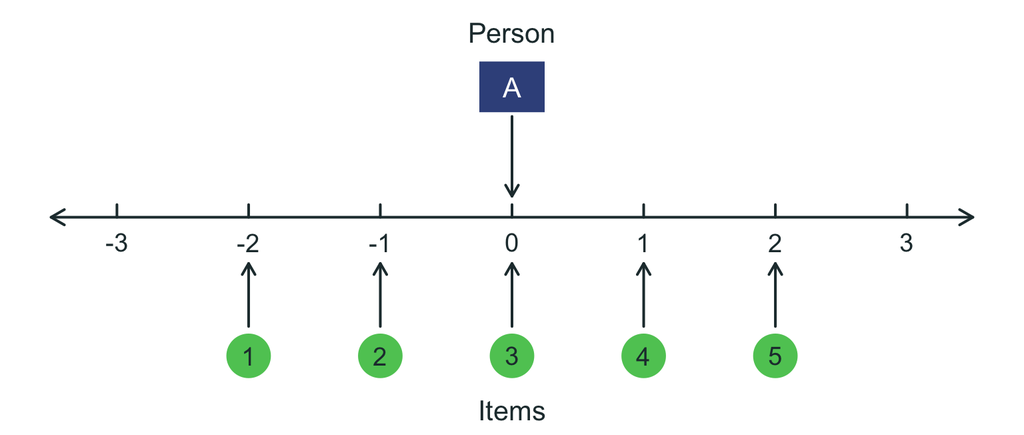

Abbildung 1: Latentes Kontinuum mit einer Person und fünf Items (nach De Ayala, 2009, S. 12)

## Rasch-Modell

**Modellgleichung**

$$P(u_{ij} = 1 \mid \theta_i, \beta_j) = \frac{e^{\theta_i - \beta_j}}{1 + e^{\theta_i - \beta_j}}
\tag{1}$$

- $\theta$: latente Variable (Fähigkeit/Eigenschaft)
- $\beta$: Itemschwierigkeit

Modelliert wird die Wahrscheinlichkeit, dass Person $i$ mit Fähigkeit $\theta_i$ ein Item $j$ mit der Schwierigkeit $\beta_j$ löst.

## Rasch-Modell

**Item Characteristic Curve (ICC)**

Verlauf der Lösungswahrscheinlichkeit für ein Item in Abhängigkeit von der Personenfähigkeit

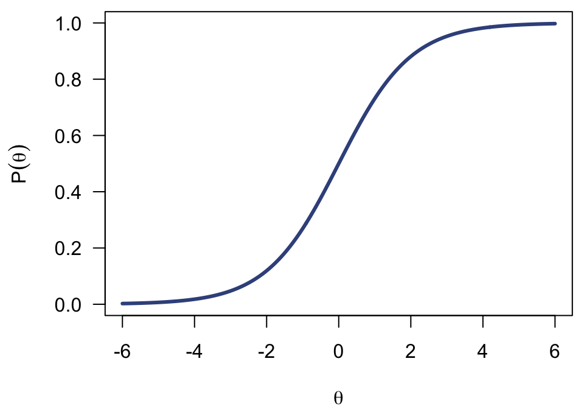

## Rasch-Modell

**Annahmen und Eigenschaften**

1. Suffiziente Statistiken
2. Eindimensionalität
3. Lokale stochastische Unabhängigkeit
4. Spezifische Objektivität

## Rasch-Modell

**Normierung und Messniveau**

- Skala der Personenfähigkeiten und Itemschwierigkeiten ist eine latente Skala $\rightarrow$ Skala besitzt keinen natürlichen Ursprung
- Bei der Normierung wird der Nullpunkt festgelegt

**Summennormierung**

Summe der Itemschwierigkeiten als Nullpunkt:

$$\sum_{j=1}^{m} \beta_j = 0
\tag{2}$$

**Mittelpunktsnormierung**

Mittelwert der Personenparameter als Nullpunkt:

$$\overline{\theta} = \frac{1}{N} \sum_{i=1}^{N} \theta_i = 0
\tag{3}$$

## 1PL-, 2PL- und 3PL-Modell

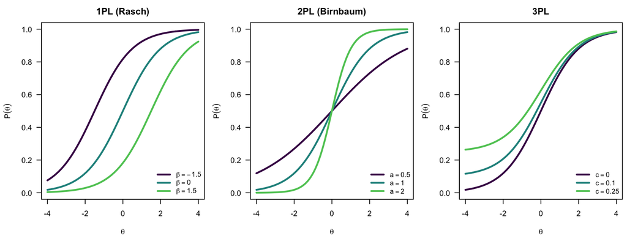

Abbildung 2: Itemcharakteristische Kurven im 1PL-, 2PL- und 3PL-Modell

## 1PL-, 2PL- und 3PL-Modell

**1PL:** nur Schwierigkeit $\beta$

$$P(\theta) = \frac{1}{1 + e^{-(\theta - \beta)}}$$

**2PL:** + Diskrimination $a$

$$P(\theta) = \frac{1}{1 + e^{-a(\theta - \beta)}}$$

**3PL:** + Rateparameter $c$

$$P(\theta) = c + \frac{1 - c}{1 + e^{-a(\theta - \beta)}}$$

# Anwendung: IRT in R

## R-Pakete für IRT

`library(mirt)`

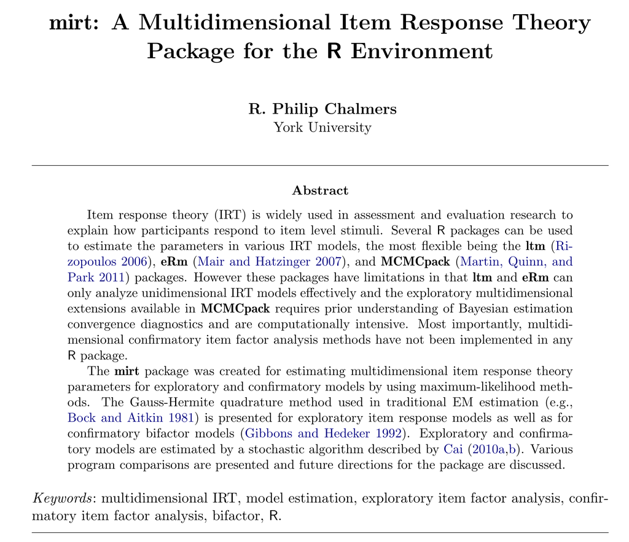

(Chalmers, 2012)

`library(eRm)`

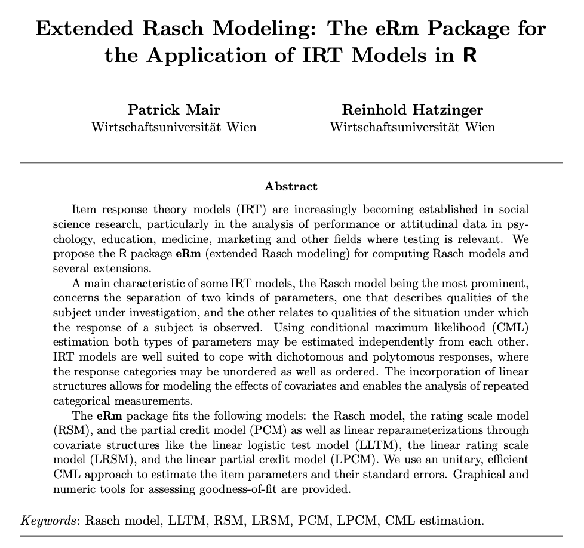

(Mair & Hatzinger, 2007)

## library(mirt)

**Zentrale Funktion:** `mirt()`

**Argumente**

- `data`: `matrix` oder `data.frame`, bei der jede Zeile die Antworten einer Person repräsentiert
- `model`: Angabe der Anzahl der Faktoren oder eines mit `mirt.model()` definierten Objekts für komplexere Ladungsmuster
- `itemtype`: Auswahl des IRT-Modells, z. B. „Rasch“, „2PL“ oder „3PL“ (Default ist 2PL)

## Spickzettel – Rasch-Modell in R

```r
# load the mirt package
library(mirt)

# Rasch model
rm1 <- mirt(data = dat, model = 1, itemtype = "Rasch")
#                   |           |                |
#               data set    number of       model type
#                       latent variables
```

## Spickzettel – Rasch-Modell in R

```r
# item difficulties
coef(object = rm1, simplify = TRUE, IRTpars = TRUE)$items

# person parameters
rm1.thetas <- fscores(object = rm1, method = "EAP")

# plot the item characteristic curve (ICC)
itemplot(object = rm1, item = 1)
```

# Danke & bis nächste Woche!

# Literaturverzeichnis

## Literatur

Chalmers, R. P. (2012). mirt: A Multidimensional Item Response Theory Package for the R Environment. *Journal of Statistical Software*, *48*(6), 1–29. https://doi.org/10.18637/jss.v048.i06

De Ayala, R. J. (2009). *The Theory and Practice of Item Response Theory*. Guilford Press.

Mair, P., & Hatzinger, R. (2007). Extended Rasch Modeling: The eRm Package for the Application of IRT Models in R. *Journal of Statistical Software*, *20*(9), 1–20. https://doi.org/10.18637/jss.v020.i09